# PRUEBA TÉCNICA - JUNIOR DATA SCIENTIST

#### Dataset: WA*Fn-UseC*-HR-Employee-Attrition

#### Por: Maicol Llano Moncada

# Contenido

1. Problema a resolver con los Datos
   - 1.1 Descripción de los datos
1. Importar Librerías
2. Cargar Datos
3. Descripción, limpieza y visualización de datos
   - 4.1 Descripción del dataset
   - 4.2 Tipos de variables
   - 4.3 Datos duplicados
   - 4.4 Datos faltantes
   - 4.5 Variables numéricas
   - 4.6 Variables categóricas
   - 4.7 Label Enconding
   - 4.8 Manejo de Outliers
   - 4.9 Análisis Vibariable
1. Principal Component Analysis
2. Detección de factores críticos
   - 6.1 Variable JobSatisfaction
     - 6.1.1 Visualización de factores críticos - Top 10
     - 6.1.2 Comparación Top 10
     - 6.1.3 Comparación con otros factores
     - 6.1.4 Análisis con otros factores
1. Conclusiones factores críticos
   - 7.1 Recomendaciones
1. DashBoard Monitoreo de indicadores
   - 8.1 Pairplot DashBoard
   - 8.2 Regplot DashBoard
   - 8.3 Distplot DashBoard - JobSatisfaction
1. Algoritmos de clasificación para predecir la decersión laboral
   - 9.1 Preparación del Dataset
   - 9.2 Aplicación de modelos
   - 9.3 Visualización de resultados
   - 9.4 Cross-Validation
   - 9.5 Visualización de resultados
   - 9.6 Comparación de resultados
   - 9.7 Optimización de Hiperparametros

# 1. Problema a resolver con los Datos

Se parte de un dataset que contiene información acerca de los trabajadores de una compañía en relación son su cargo:

1. Encontrar los factores críticos que hacen que un empleado esté o no satisfecho (variable JobSatisfaction).
1. Construir un dashboard que ayude a monitorear los indicadores relevantes para mantener una satisfacción alta.

## 1.1 Descripción de los datos

- Cantidad de variables: 35
- Cantidad de instancias: 1470

### Significado de cada variable:

- Age: Edad del trabajdor
- Attrition: Dejó la compañía (Si/No)
- BusinessTravel: Indica la frecuencia de viajes con motivos laborales
- DailyRate: Salario Diario
- Department: Departamento en el que trabajo el empleado
- DistanceFromHome: Distancia del hogar al lugar de trabajo
- Education: Nivel de educación del trabajador
- EducationField: Área de educación
- EmployeeCount: Cuenta de empleados
- EmployeeNumber: Número de empleado
- EnvironmentSatisfaction: Satisfacción con el ambiente
- Gender: Género del empleado
- HourlyRate: Salario por hora
- JobInvolvement: implicación laboral
- JobLevel: Nivel de trabajo
- JobRole: Rol del trabajador
- JobSatisfaction: Satisfacción del trabajor
- MaritalStatus: Estado marital del trabajador
- MonthlyIncome: Ingreso mensual
- MonthlyRate: Salario total Mensual
- NumCompaniesWorked: Número de compañías en las que ha trabajado
- Over18: Indica si es mayor de 18 años
- OverTime: Horas extra
- PercentSalaryHike: Porcentaje de aumento de salario
- PerformanceRating: Nivel de desempeño
- RelationshipSatisfaction: Satisfacción con las relaciones
- StandardHours: Horas estándar
- StockOptionLevel: Nivel de compra de acciones
- TotalWorkingYears: Total de años trabajando
- TrainingTimesLastYear: Ocasiones de entrenamiento el año pasado
- WorkLifeBalance: Equilibrio trabajo-vida
- YearsAtCompany: Años en la compañía
- YearsInCurrentRole: Años en el cargo actual
- YearsSinceLastPromotion: Años desde la última promoción
- YearsWithCurrManager: Años con el jefe actual

# 2. Importar Librerías

```python
# Importar librerias

%matplotlib inline
import matplotlib.pyplot as plt
import numpy as np
import pandas as pd
import seaborn as sns
import math
import warnings; warnings.simplefilter('ignore')
from IPython.core.display import HTML
```

# 3. Cargar Datos

```python
df = pd.read_excel('WA_Fn-UseC_-HR-Employee-Attrition.xlsx',encoding='utf_8')

# Se observa el head del dataframe

display(HTML(df.head(6).to_html()))  # Muestra todas las variables de los primeros 5 registros del datagra
```

|  | Age | Attrition | BusinessTravel | DailyRate | Department | DistanceFromHome | Education | EducationField | EmployeeCount | EmployeeNumber | EnvironmentSatisfaction | Gender | HourlyRate | JobInvolvement | JobLevel | JobRole | JobSatisfaction | MaritalStatus | MonthlyIncome | MonthlyRate | NumCompaniesWorked | Over18 | OverTime | PercentSalaryHike | PerformanceRating | RelationshipSatisfaction | StandardHours | StockOptionLevel | TotalWorkingYears | … |
| --- | --- | --- | --- | --- | --- | --- | --- | --- | --- | --- | --- | --- | --- | --- | --- | --- | --- | --- | --- | --- | --- | --- | --- | --- | --- | --- | --- | --- | --- | --- |
| 0 | 41 | Yes | Travel_Rarely | 1102 | Sales | 1 | 2 | Life Sciences | 1 | 1 | 2 | Female | 94 | 3 | 2 | Sales Executive | 4 | Single | 5993 | 19479 | 8 | Y | Yes | 11 | 3 | 1 | 80 | 0 | 8 | … |
| 1 | 49 | No | Travel_Frequently | 279 | Research & Development | 8 | 1 | Life Sciences | 1 | 2 | 3 | Male | 61 | 2 | 2 | Research Scientist | 2 | Married | 5130 | 24907 | 1 | Y | No | 23 | 4 | 4 | 80 | 1 | 10 | … |
| 2 | 37 | Yes | Travel_Rarely | 1373 | Research & Development | 2 | 2 | Other | 1 | 4 | 4 | Male | 92 | 2 | 1 | Laboratory Technician | 3 | Single | 2090 | 2396 | 6 | Y | Yes | 15 | 3 | 2 | 80 | 0 | 7 | … |
| 3 | 33 | No | Travel_Frequently | 1392 | Research & Development | 3 | 4 | Life Sciences | 1 | 5 | 4 | Female | 56 | 3 | 1 | Research Scientist | 3 | Married | 2909 | 23159 | 1 | Y | Yes | 11 | 3 | 3 | 80 | 0 | 8 | … |
| 4 | 27 | No | Travel_Rarely | 591 | Research & Development | 2 | 1 | Medical | 1 | 7 | 1 | Male | 40 | 3 | 1 | Laboratory Technician | 2 | Married | 3468 | 16632 | 9 | Y | No | 12 | 3 | 4 | 80 | 1 | 6 | … |
| 5 | 32 | No | Travel_Frequently | 1005 | Research & Development | 2 | 2 | Life Sciences | 1 | 8 | 4 | Male | 79 | 3 | 1 | Laboratory Technician | 4 | Single | 3068 | 11864 | 0 | Y | No | 13 | 3 | 3 | 80 | 0 | 8 | … |

# 4. Descripción, limpieza y visualización de datos

## 4.1 Descripción del dataset

```python
#tamaño del dataframe

df.shape
```

```
(1470, 35)
```

- El dataframe contiene1470 registros y 35 variables

```python
print('Numero de instancias = {}'.format(len(df)))
```

```
Numero de instancias = 1470
```

```python
# Realizar un analisis estadistico de las variables numéricas

display(HTML(df.describe().to_html()))
```

|  | Age | DailyRate | DistanceFromHome | Education | EmployeeCount | EmployeeNumber | EnvironmentSatisfaction | HourlyRate | JobInvolvement | JobLevel | JobSatisfaction | MonthlyIncome | MonthlyRate | NumCompaniesWorked | PercentSalaryHike | PerformanceRating | RelationshipSatisfaction | StandardHours | StockOptionLevel | TotalWorkingYears | TrainingTimesLastYear | WorkLifeBalance | YearsAtCompany | YearsInCurrentRole | YearsSinceLastPromotion | YearsWithCurrManager |
| --- | --- | --- | --- | --- | --- | --- | --- | --- | --- | --- | --- | --- | --- | --- | --- | --- | --- | --- | --- | --- | --- | --- | --- | --- | --- | --- |
| count | 1470.000000 | 1470.000000 | 1470.000000 | 1470.000000 | 1470.0 | 1470.000000 | 1470.000000 | 1470.000000 | 1470.000000 | 1470.000000 | 1470.000000 | 1470.000000 | 1470.000000 | 1470.000000 | 1470.000000 | 1470.000000 | 1470.000000 | 1470.0 | 1470.000000 | 1470.000000 | 1470.000000 | 1470.000000 | 1470.000000 | 1470.000000 | 1470.000000 | 1470.000000 |
| mean | 36.923810 | 802.485714 | 9.192517 | 2.912925 | 1.0 | 1024.865306 | 2.721769 | 65.891156 | 2.729932 | 2.063946 | 2.728571 | 6502.931293 | 14313.103401 | 2.693197 | 15.209524 | 3.153741 | 2.712245 | 80.0 | 0.793878 | 11.279592 | 2.799320 | 2.761224 | 7.008163 | 4.229252 | 2.187755 | 4.123129 |
| std | 9.135373 | 403.509100 | 8.106864 | 1.024165 | 0.0 | 602.024335 | 1.093082 | 20.329428 | 0.711561 | 1.106940 | 1.102846 | 4707.956783 | 7117.786044 | 2.498009 | 3.659938 | 0.360824 | 1.081209 | 0.0 | 0.852077 | 7.780782 | 1.289271 | 0.706476 | 6.126525 | 3.623137 | 3.222430 | 3.568136 |
| min | 18.000000 | 102.000000 | 1.000000 | 1.000000 | 1.0 | 1.000000 | 1.000000 | 30.000000 | 1.000000 | 1.000000 | 1.000000 | 1009.000000 | 2094.000000 | 0.000000 | 11.000000 | 3.000000 | 1.000000 | 80.0 | 0.000000 | 0.000000 | 0.000000 | 1.000000 | 0.000000 | 0.000000 | 0.000000 | 0.000000 |
| 25% | 30.000000 | 465.000000 | 2.000000 | 2.000000 | 1.0 | 491.250000 | 2.000000 | 48.000000 | 2.000000 | 1.000000 | 2.000000 | 2911.000000 | 8047.000000 | 1.000000 | 12.000000 | 3.000000 | 2.000000 | 80.0 | 0.000000 | 6.000000 | 2.000000 | 2.000000 | 3.000000 | 2.000000 | 0.000000 | 2.000000 |
| 50% | 36.000000 | 802.000000 | 7.000000 | 3.000000 | 1.0 | 1020.500000 | 3.000000 | 66.000000 | 3.000000 | 2.000000 | 3.000000 | 4919.000000 | 14235.500000 | 2.000000 | 14.000000 | 3.000000 | 3.000000 | 80.0 | 1.000000 | 10.000000 | 3.000000 | 3.000000 | 5.000000 | 3.000000 | 1.000000 | 3.000000 |
| 75% | 43.000000 | 1157.000000 | 14.000000 | 4.000000 | 1.0 | 1555.750000 | 4.000000 | 83.750000 | 3.000000 | 3.000000 | 4.000000 | 8379.000000 | 20461.500000 | 4.000000 | 18.000000 | 3.000000 | 4.000000 | 80.0 | 1.000000 | 15.000000 | 3.000000 | 3.000000 | 9.000000 | 7.000000 | 3.000000 | 7.000000 |
| max | 60.000000 | 1499.000000 | 29.000000 | 5.000000 | 1.0 | 2068.000000 | 4.000000 | 100.000000 | 4.000000 | 5.000000 | 4.000000 | 19999.000000 | 26999.000000 | 9.000000 | 25.000000 | 4.000000 | 4.000000 | 80.0 | 3.000000 | 40.000000 | 6.000000 | 4.000000 | 40.000000 | 18.000000 | 15.000000 | 17.000000 |

## 4.2 Tipos de variables

```python
#Tipos de variables

print(df.dtypes.to_string())
```

```
Age                          int64
Attrition                   object
BusinessTravel              object
DailyRate                    int64
Department                  object
DistanceFromHome             int64
Education                    int64
EducationField              object
EmployeeCount                int64
EmployeeNumber               int64
EnvironmentSatisfaction      int64
Gender                      object
HourlyRate                   int64
JobInvolvement               int64
JobLevel                     int64
JobRole                     object
JobSatisfaction              int64
MaritalStatus               object
MonthlyIncome                int64
MonthlyRate                  int64
NumCompaniesWorked           int64
Over18                      object
OverTime                    object
PercentSalaryHike            int64
PerformanceRating            int64
RelationshipSatisfaction     int64
StandardHours                int64
StockOptionLevel             int64
TotalWorkingYears            int64
TrainingTimesLastYear        int64
WorkLifeBalance              int64
YearsAtCompany               int64
YearsInCurrentRole           int64
YearsSinceLastPromotion      int64
YearsWithCurrManager         int64
```

```python
df.dtypes.value_counts()
```

```
int64     26
object     9
dtype: int64
```

- Se tienen 26 variables numéricas y 9 categóricas

## 4.3 Datos duplicados

```python
#Cantidad de datos duplicados

df[df.duplicated()==True].shape
```

```
(0, 35)
```

- No existen datos duplicados

## 4.4 Datos faltantes

```python
#Se verifica cuáles variables tienen valores faltantes

df.isnull().sum()[df.isnull().sum()>0]
```

```
Series([], dtype: int64)
```

```python
# Cantidad de instancias con datos nulos

print(df.isnull().sum(axis=1)[df.isnull().sum(axis=1)>0].shape)
```

```
(0,)
```

- El dataset no tiene datos faltantes

## 4.5 Variables numéricas

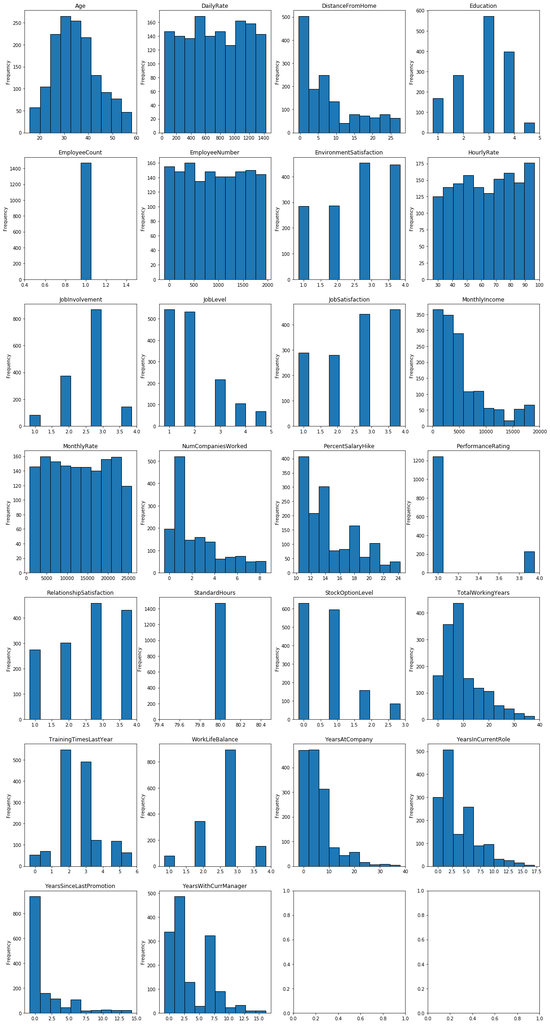

```python
d=df.dtypes[df.dtypes=='int64'].index.values


fig, axes = plt.subplots(nrows=7, ncols=4, figsize=(20,40));
contador=0;
for x in range(7):
    for y in range(4):
        df[d[contador]].plot.hist(align='left',ec='black',ax=axes[x,y]);
        axes[x,y].set_title(d[contador])

        contador+=1
        if contador==26: break
```

###### Se observa que las variables StandardHours y EmployeeCount solo tienen un posible valor por lo que pierden relevancia a la hora realizar análisis con los datos. Por lo tanto, se decide eliminarlas:

```python
df.drop(['StandardHours','EmployeeCount'],axis=1,inplace=True)
```

###### Se observa que la variable EmployeeNumeber no tiene relevancia a la hora realizar análisis con los datos, ya que es un simple identificador de empleado. Por lo tanto, se decide eliminarla:

```python
df.drop(['EmployeeNumber'],axis=1,inplace=True)
```

## 4.6 Variables categóricas

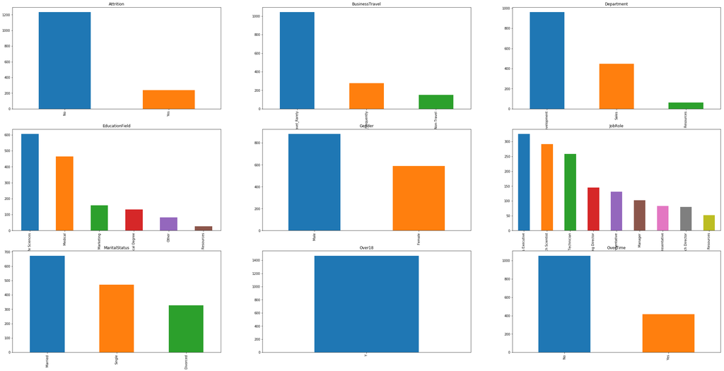

```python
d=df.dtypes[df.dtypes=='object'].index.values


fig, axes = plt.subplots(nrows=3, ncols=3, figsize=(40,20));

contador=0;
for x in range(3):
    for y in range(3):
        df[d[contador]].value_counts().plot(kind='bar',ax=axes[x,y]);
        axes[x,y].set_title(d[contador])
        contador+=1
        if contador==94: break
```

###### Se observa que las variable Over18 solo tiene un posible valor por lo que pierde relevancia a la hora realizar análisis con los datos. Por lo tanto, se decide eliminarla:

```python
df.drop('Over18',axis=1,inplace=True)
```

## 4.7 Label Encoding

- Se procede a transformar las variables categóricas restantes en numéricas y crear un dataframe equivalente, con el fin de realizar análisis de correlación entretodas las variables.

```python
from sklearn import preprocessing

encoded_df=df.copy()

for column in df.columns:
    if df[column].dtype == type(object):
        le = preprocessing.LabelEncoder()
        encoded_df[column] = le.fit_transform(df[column])


encoded_df.describe()
```

|  | Age | Attrition | BusinessTravel | DailyRate | Department | DistanceFromHome | Education | EducationField | EnvironmentSatisfaction | Gender | ... | PerformanceRating | RelationshipSatisfaction | StockOptionLevel | TotalWorkingYears | TrainingTimesLastYear | WorkLifeBalance | YearsAtCompany | YearsInCurrentRole | YearsSinceLastPromotion | YearsWithCurrManager |
| --- | --- | --- | --- | --- | --- | --- | --- | --- | --- | --- | --- | --- | --- | --- | --- | --- | --- | --- | --- | --- | --- |
| count | 1470.000000 | 1470.000000 | 1470.000000 | 1470.000000 | 1470.000000 | 1470.000000 | 1470.000000 | 1470.000000 | 1470.000000 | 1470.000000 | ... | 1470.000000 | 1470.000000 | 1470.000000 | 1470.000000 | 1470.000000 | 1470.000000 | 1470.000000 | 1470.000000 | 1470.000000 | 1470.000000 |
| mean | 36.923810 | 0.161224 | 1.607483 | 802.485714 | 1.260544 | 9.192517 | 2.912925 | 2.247619 | 2.721769 | 0.600000 | ... | 3.153741 | 2.712245 | 0.793878 | 11.279592 | 2.799320 | 2.761224 | 7.008163 | 4.229252 | 2.187755 | 4.123129 |
| std | 9.135373 | 0.367863 | 0.665455 | 403.509100 | 0.527792 | 8.106864 | 1.024165 | 1.331369 | 1.093082 | 0.490065 | ... | 0.360824 | 1.081209 | 0.852077 | 7.780782 | 1.289271 | 0.706476 | 6.126525 | 3.623137 | 3.222430 | 3.568136 |
| min | 18.000000 | 0.000000 | 0.000000 | 102.000000 | 0.000000 | 1.000000 | 1.000000 | 0.000000 | 1.000000 | 0.000000 | ... | 3.000000 | 1.000000 | 0.000000 | 0.000000 | 0.000000 | 1.000000 | 0.000000 | 0.000000 | 0.000000 | 0.000000 |
| 25% | 30.000000 | 0.000000 | 1.000000 | 465.000000 | 1.000000 | 2.000000 | 2.000000 | 1.000000 | 2.000000 | 0.000000 | ... | 3.000000 | 2.000000 | 0.000000 | 6.000000 | 2.000000 | 2.000000 | 3.000000 | 2.000000 | 0.000000 | 2.000000 |
| 50% | 36.000000 | 0.000000 | 2.000000 | 802.000000 | 1.000000 | 7.000000 | 3.000000 | 2.000000 | 3.000000 | 1.000000 | ... | 3.000000 | 3.000000 | 1.000000 | 10.000000 | 3.000000 | 3.000000 | 5.000000 | 3.000000 | 1.000000 | 3.000000 |
| 75% | 43.000000 | 0.000000 | 2.000000 | 1157.000000 | 2.000000 | 14.000000 | 4.000000 | 3.000000 | 4.000000 | 1.000000 | ... | 3.000000 | 4.000000 | 1.000000 | 15.000000 | 3.000000 | 3.000000 | 9.000000 | 7.000000 | 3.000000 | 7.000000 |
| max | 60.000000 | 1.000000 | 2.000000 | 1499.000000 | 2.000000 | 29.000000 | 5.000000 | 5.000000 | 4.000000 | 1.000000 | ... | 4.000000 | 4.000000 | 3.000000 | 40.000000 | 6.000000 | 4.000000 | 40.000000 | 18.000000 | 15.000000 | 17.000000 |

8 rows × 31 columns

- Se visualizan nuevamente las variables que fueron convertidas a numéricas

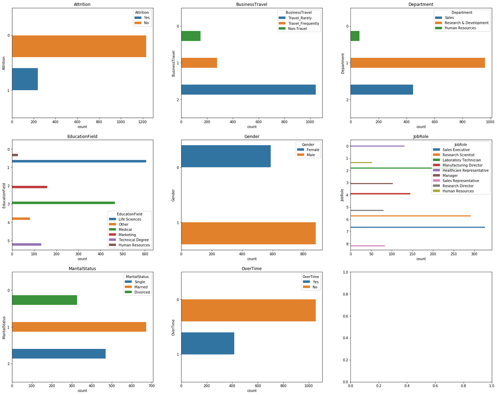

```python
d=['Attrition','BusinessTravel','Department','EducationField','Gender',
 'JobRole','MaritalStatus','OverTime']

fig, axes = plt.subplots(nrows=3, ncols=3, figsize=(25,20));
contador=0;
for x in range(3):
    for y in range(3):

        #encoded_df[d[contador]].value_counts().plot(kind='bar',ax=axes[x,y]);
        sns.countplot(y=encoded_df[d[contador]],data=df,hue=df[d[contador]],ax=axes[x,y])
        axes[x,y].set_title(d[contador])

        contador+=1
        if contador==8: break
```

## 4.8 Manejo de Outliers

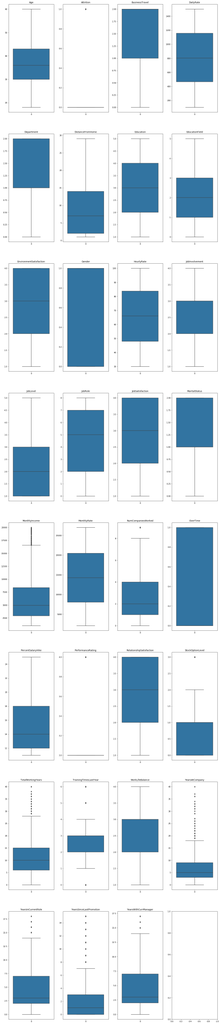

```python
d=df.dtypes.index.values

fig, axes = plt.subplots(nrows=8, ncols=4, figsize=(20,100));
contador=0;
for x in range(8):
    for y in range(4):
        sns.boxplot(data=encoded_df[d[contador]],ax=axes[x,y])
        axes[x,y].set_title(d[contador])
        contador+=1
        if contador==31: break
```

###### Aunque el análisis confirma que el Dataset contiene Outliers, no se evidencia que dichos valores en realidad estén por fuera de lo que se espera de acuerdo con su variable correspondiente

## 4.9 Análisis Vibariable

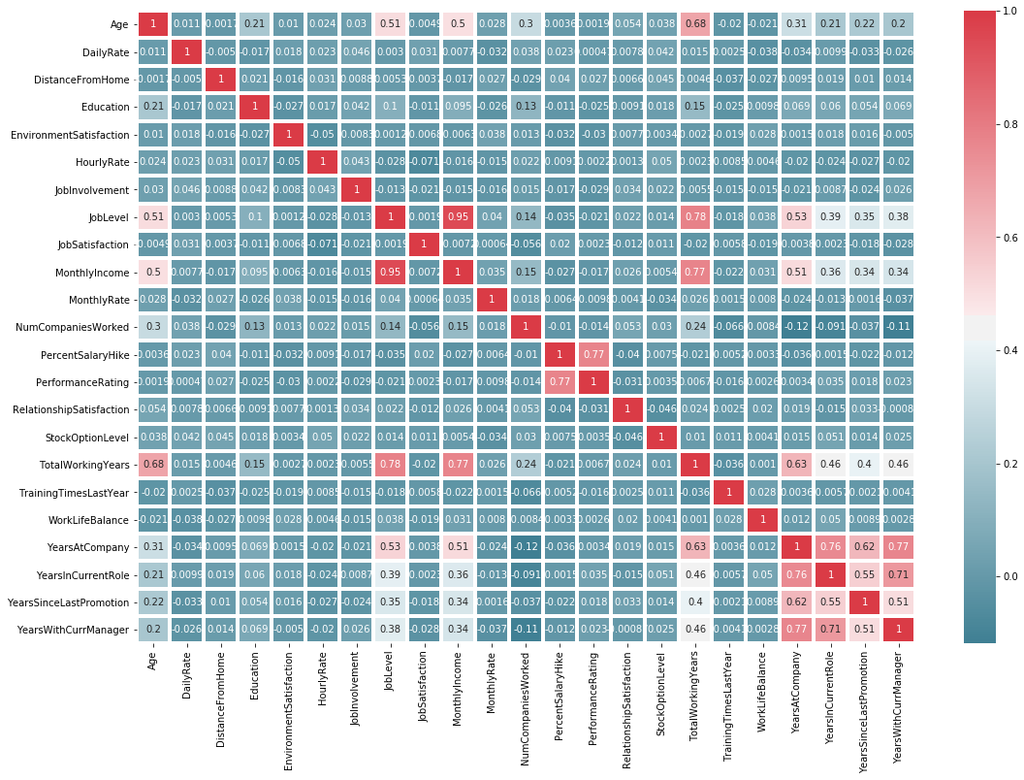

```python
plt.figure(figsize=(18,12))
cmap=sns.diverging_palette(220,10,as_cmap=True)
sns.heatmap(df.corr(),xticklabels=df.corr().columns.values,yticklabels=df.corr().index.values,cmap=cmap,linewidths=3,annot=True);
```

- Se observa que no hay datos altamente correlacionados con la variable objetivo (JobSatisfaction)

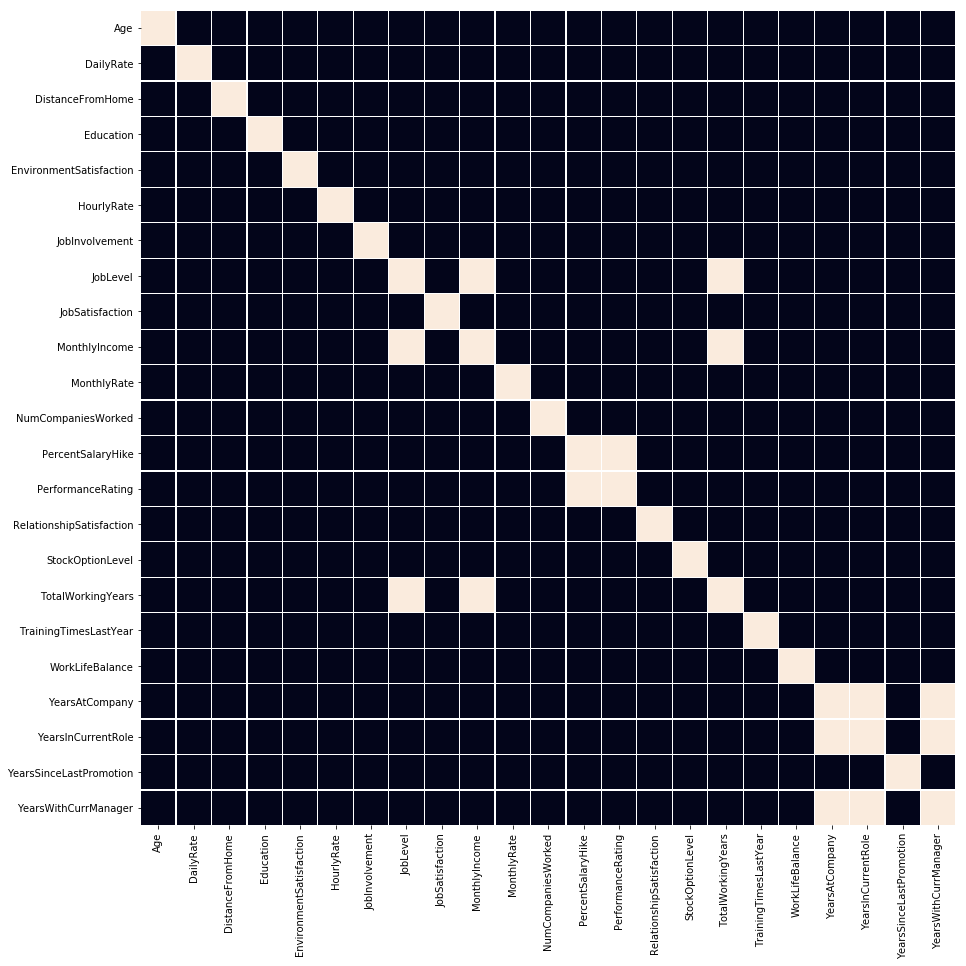

```python
d=df.dtypes[df.dtypes=='int64'].index.values

mat_corr = df[d].corr()


mat_corr_int = (mat_corr>0.7).astype(int)

# Dibuja el heat map, donde los cuadros blancos serán donde hay una correlación > 0.7.

fig, axes = plt.subplots(figsize=(15, 15))
sns.heatmap(mat_corr_int, linewidths=.2, square=True, cbar=False,);
```

Se observa que:

- El total de años trabajados influye altamente en el nivel del trabajo y en el salario, esto puede explicarse debido a la experiencia que ha adquirido la persona
- El desempeño influye en el porcentaje de aumento del salario
- Los años en la compañía están relacionados con los años en el cargo y los años con el jefe actual

Una vez más se comprueba que no hay datos altamente correlacionados con la variable objetivo

# 5. Principal Component Analysis

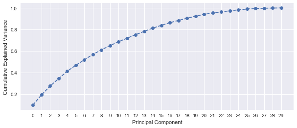

```python
from sklearn.decomposition import PCA
from sklearn.preprocessing import MinMaxScaler

def plt_pca(df):

    pca = PCA(df.shape[1]-1)
    projected = pca.fit_transform(MinMaxScaler().fit_transform(df.drop(['JobSatisfaction'],axis=1)))
    pca_inversed_data = pca.inverse_transform(np.eye(df.shape[1]-1))

    plt.style.use('seaborn')

    plt.figure(figsize = (10, 4))
    plt.plot(np.cumsum(pca.explained_variance_ratio_), '--o')
    plt.xlabel('Principal Component')
    plt.ylabel('Cumulative Explained Variance')
    plt.xticks(np.arange(0, df.shape[1]-1, 1.0))
    plt.show()


plt_pca(encoded_df)
```

###### De acuerdo con el análisis PCA, casi el 100% de la variabilidad del Dataset se puede explicar con 25-26 variables. Este análisis se tendrá como pauta para realizar el proceso de selección de variables basado en pruebas estadísticas univariadas (SelectKBest)

# 6. Detección de factores críticos

Se realizará un análisis estadístico entre las variables de entrada y nuestro target, con el objetivo de determinar cuáles están más relacionadas, es decir que tienen una dependencia lineal marcada. (Para llevar a cabo este análisis se usará la función SelectKBest que realiza los análisis basada en una función de test que como se dijo anteriormente estimaelgrado dedependencia lineal entre dos variables aleatorias).

## 6.1 Variable JobSatisfaction

```python
from sklearn.feature_selection import SelectKBest

# Funcion para identificar mejores variables basadas en pruebas estadísticas univariadas
def Feature_Selection(df,target):
    select = SelectKBest()
    select.fit(df.drop([target],axis=1), df[target])
    scores = select.scores_
    feature_scores = pd.DataFrame({'columnas': df.drop([target],axis=1).columns.tolist(),'scores': scores.tolist(),})
    return feature_scores.sort_values(by='scores',ascending=False)
```

```python
# Funcion para identificar mejores variables basadas en pruebas estadísticas univariadas
Feature_Selection(encoded_df,'JobSatisfaction')
```

|  | columnas | scores |
| --- | --- | --- |
| 1 | Attrition | 5.889279 |
| 10 | HourlyRate | 2.795356 |
| 3 | DailyRate | 1.769586 |
| 17 | NumCompaniesWorked | 1.597170 |
| 20 | PerformanceRating | 1.338122 |
| 2 | BusinessTravel | 1.311727 |
| 18 | OverTime | 1.229103 |
| 19 | PercentSalaryHike | 1.091841 |
| 7 | EducationField | 1.013069 |
| 8 | EnvironmentSatisfaction | 0.886221 |
| 9 | Gender | 0.848387 |
| 29 | YearsWithCurrManager | 0.652751 |
| 4 | Department | 0.515992 |
| 16 | MonthlyRate | 0.513275 |
| 25 | WorkLifeBalance | 0.467883 |
| 24 | TrainingTimesLastYear | 0.433178 |
| 22 | StockOptionLevel | 0.393381 |
| 14 | MaritalStatus | 0.326699 |
| 23 | TotalWorkingYears | 0.275942 |
| 11 | JobInvolvement | 0.261526 |
| 28 | YearsSinceLastPromotion | 0.209156 |
| 5 | DistanceFromHome | 0.186577 |
| 13 | JobRole | 0.167207 |
| 6 | Education | 0.134041 |
| 27 | YearsInCurrentRole | 0.121827 |
| 21 | RelationshipSatisfaction | 0.115029 |
| 0 | Age | 0.051798 |
| 12 | JobLevel | 0.045785 |
| 26 | YearsAtCompany | 0.033558 |
| 15 | MonthlyIncome | 0.027039 |

###### Se observa que

- Una de las variables que más se relaciona con nuestro target es la de Atrittion, la cual indica si una persona dejó la compañía, de acuerdo con esto, esta variable será tenida en cuenta para análisis futuros con el objetivo de identificar factores que llevan a que una persona deje la compañía por el hecho de estar insatisfecho con su trabajo. Esta relación se puede entender fácilmente ya que es muy probable que si una persona está inconforme con su trabajo abandonde la compañía.

```python
# Se obtiene el TOP 10 de factores que influyen con la satisfacción laboral

Feature_Selection(encoded_df,'JobSatisfaction').head(10)['columnas'].values
```

```
array(['Attrition', 'HourlyRate', 'DailyRate', 'NumCompaniesWorked',
       'PerformanceRating', 'BusinessTravel', 'OverTime',
       'PercentSalaryHike', 'EducationField', 'EnvironmentSatisfaction'],
      dtype=object)
```

### 6.1.1 Visualización de factores críticos - Top 10

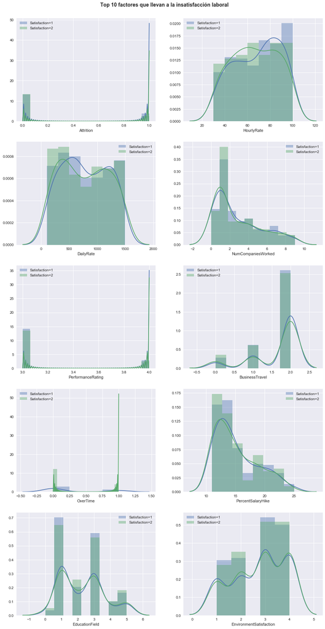

```python
plt.figure(figsize=(15,30))

d=Feature_Selection(encoded_df,'JobSatisfaction').head(10)['columnas'].values
for i in range(10):

    plt.subplot(5,2,i+1)
    sns.distplot(encoded_df[d[i]][encoded_df['JobSatisfaction']==1],label='Satisfaction=1');
    sns.distplot(encoded_df[d[i]][encoded_df['JobSatisfaction']==2],label='Satisfaction=2');
    plt.suptitle("Top 10 factores que llevan a la insatisfacción laboral",y=0.9,fontsize=14, fontweight='bold');
    plt.legend();
```

#### Análisis de las gráficas:

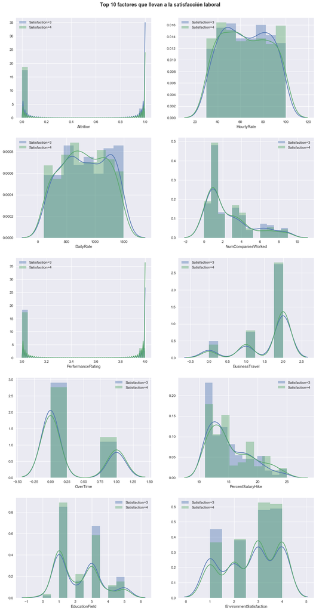

```python
plt.figure(figsize=(15,30))

d=Feature_Selection(encoded_df,'JobSatisfaction').head(10)['columnas'].values
for i in range(10):

    plt.subplot(5,2,i+1)
    sns.distplot(encoded_df[d[i]][encoded_df['JobSatisfaction']==3],label='Satisfaction=3');
    sns.distplot(encoded_df[d[i]][encoded_df['JobSatisfaction']==4],label='Satisfaction=4');
    plt.suptitle("Top 10 factores que llevan a la satisfacción laboral",y=0.9,fontsize=14, fontweight='bold');
    plt.legend();
```

#### Análisis de las gráficas:

- Se puede ver que un mayor porcentaje de personas que no dejaron la compañía tenían niveles altos de satisfacción
- A pesar de que el pago por hora sea bajo, hay niveles altos de satisfacción, esto da a enteder que existen otros factores determinantes para que haya satisfacción laboral
- El Daily Rate confirma nuevamente que para quienes están satisfechos, el factor más determinante no es el dinero.
- Las personas más insatisfechas son aquellas que han trabajado en una compañía. A medida que las personas tienen más experiencia la insatisfacción se reduce
- Hay más personas satisfechas que insatisfechas a pesar de no tener el mejor desempeño
- Aquellas personas que tienen un empleo que implica viajar frecuentemenete, tienen altos niveles de satisfacción. Esto muestra contradicción con lo hayado para los niveles de satisfacción bajos, esto puede pasar debido a que los datos están desbalanceados y es un indicador de que los viajes no son un factor muy relevante para medir la satisfacción.
- Una buena satisfacción con el ambiente lleva a una buena satisfacción laboral

### 6.1.2 Comparación Top 10

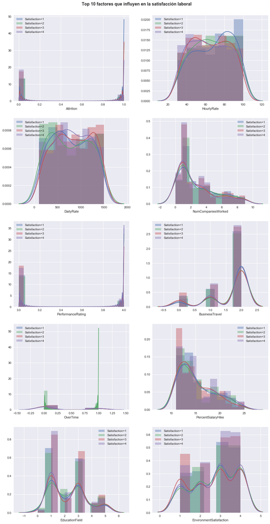

```python
plt.figure(figsize=(15,30))

d=Feature_Selection(encoded_df,'JobSatisfaction').head(10)['columnas'].values
for i in range(10):

    plt.subplot(5,2,i+1)
    sns.distplot(encoded_df[d[i]][encoded_df['JobSatisfaction']==1],label='Satisfaction=1');
    sns.distplot(encoded_df[d[i]][encoded_df['JobSatisfaction']==2],label='Satisfaction=2');
    sns.distplot(encoded_df[d[i]][encoded_df['JobSatisfaction']==3],label='Satisfaction=3');
    sns.distplot(encoded_df[d[i]][encoded_df['JobSatisfaction']==4],label='Satisfaction=4');
    plt.suptitle("Top 10 factores que influyen en la satisfacción laboral",y=0.9,fontsize=14, fontweight='bold');
    plt.legend();
```

### Algunos comentarios:

Al realizar esta comparación, se puede observar que el comportamiento de los niveles de satisfacción e insatisfacción no tienen una diferencia muy marcada con respecto a las variables analizadas, sin embargo hay algunos casos en los que se puede ver una tendencia mínima.

#### - El pago por día y por hora es un factor determinante para la satisfacción

### 6.1.3 Comparación con otros factores

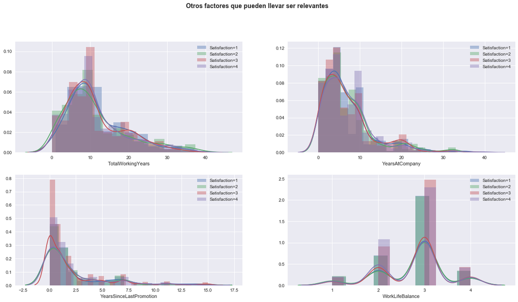

```python
plt.figure(figsize=(20,10))

d=['TotalWorkingYears','YearsAtCompany','YearsSinceLastPromotion','WorkLifeBalance']
for i in range(4):

    plt.subplot(2,2,i+1)
    sns.distplot(encoded_df[d[i]][encoded_df['JobSatisfaction']==1],label='Satisfaction=1');
    sns.distplot(encoded_df[d[i]][encoded_df['JobSatisfaction']==2],label='Satisfaction=2');
    sns.distplot(encoded_df[d[i]][encoded_df['JobSatisfaction']==3],label='Satisfaction=3');
    sns.distplot(encoded_df[d[i]][encoded_df['JobSatisfaction']==4],label='Satisfaction=4');
    plt.suptitle("Otros factores que pueden llevar ser relevantes",y=1,fontsize=14, fontweight='bold');
    plt.legend();
```

- Se observa que la gente que es recién promovida es en general más satisfecha

#### A continuación,se realizarán otros análisis con el fin de tener más claros los factores relevantes

### 6.1.4 Análisis con otros factores

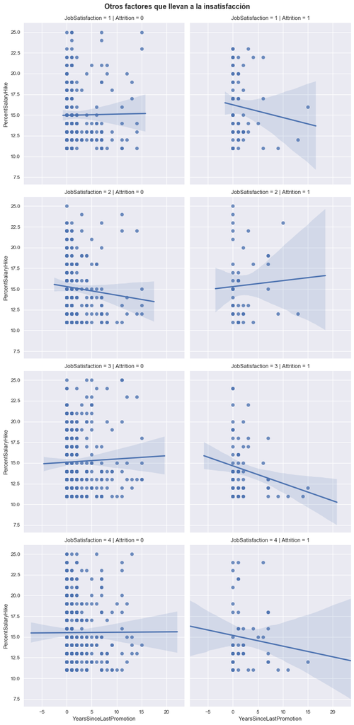

```python
g=sns.FacetGrid(encoded_df,col='Attrition',row='JobSatisfaction',size=5);
g=g.map(sns.regplot,"YearsSinceLastPromotion","PercentSalaryHike");
plt.suptitle("Otros factores que llevan a la insatisfacción",y=1.01,fontsize=14, fontweight='bold');
```

- Un dato relevante es que las personas que son promovidas y no tienen tendencia a tener un aumento porcentual de salario, lo que hace que a pesar de que estén satisfechos con su trabajo, abandonen la compañía. En el caso en que hay promoción y aumento de salario, la satisfacción aumenta y la tasa de deserción baja.

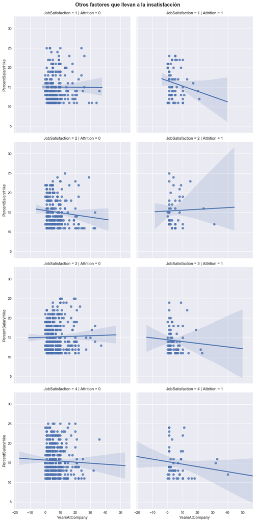

```python
g=sns.FacetGrid(encoded_df,col='Attrition',row='JobSatisfaction',size=5);
g=g.map(sns.regplot,"YearsAtCompany","PercentSalaryHike");
plt.suptitle("Otros factores que llevan a la insatisfacción",y=1.01,fontsize=14, fontweight='bold');
```

- Un dato relevante es que las personas que llevan varios años en la compañía y no tienen tendencia a tener un aumento porcentual de salario, a pesar de que estén satisfechos con su trabajo, abandonan la compañía. En el caso en que pasan los años y hay aumento de salario, la satisfacción aumenta y la tasa de deserción baja.

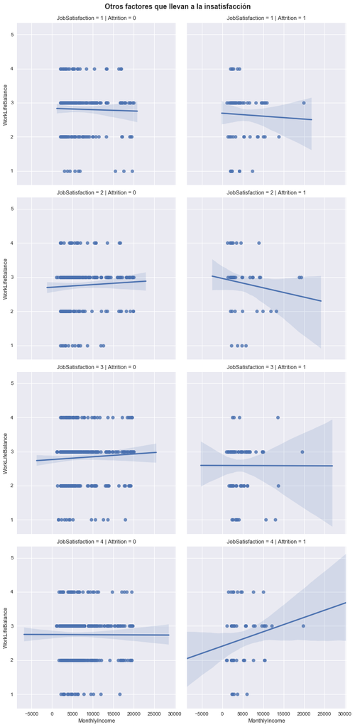

```python
g=sns.FacetGrid(encoded_df,col='Attrition',row='JobSatisfaction',size=5);
g=g.map(sns.regplot,"MonthlyIncome","WorkLifeBalance");
plt.suptitle("Otros factores que llevan a la insatisfacción",y=1.01,fontsize=14, fontweight='bold');
```

- Se observa que a medida que las personas obtienen más ganancias, tienen peor balance vida-trabajo y la tasa de abandono e insatisfacción aumenta

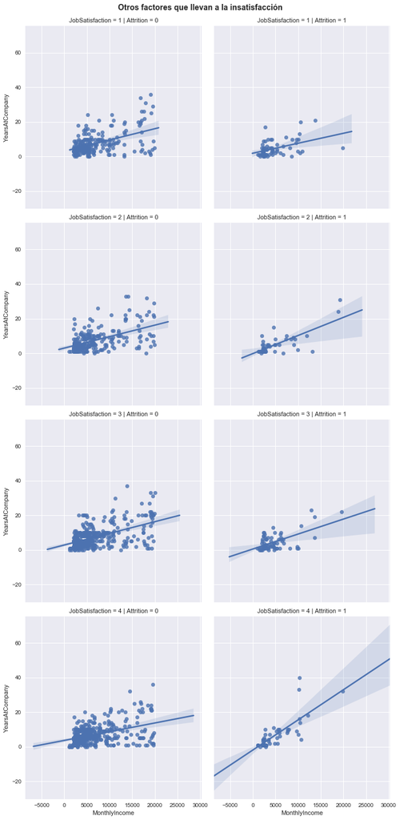

```python
g=sns.FacetGrid(encoded_df,col='Attrition',row='JobSatisfaction',size=5);
g=g.map(sns.regplot,"MonthlyIncome","YearsAtCompany");
plt.suptitle("Otros factores que llevan a la insatisfacción",y=1.01,fontsize=14, fontweight='bold');
```

- Se observa que a medida que las personas tienen más tiempo en la compañía y no existe relación directa entre el tiempo y los ingresos, se presenta insatisfacción y decersión.

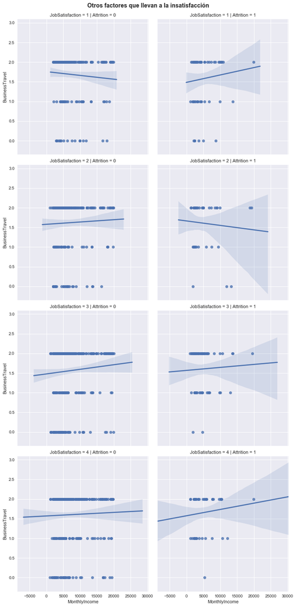

```python
g=sns.FacetGrid(encoded_df,col='Attrition',row='JobSatisfaction',size=5);
g=g.map(sns.regplot,"MonthlyIncome","BusinessTravel");
plt.suptitle("Otros factores que llevan a la insatisfacción",y=1.01,fontsize=14, fontweight='bold');
```

- Se observa que las personas más insatisfechas son aquellas que a pesar de tener altos ingresos, tienen que viajar más

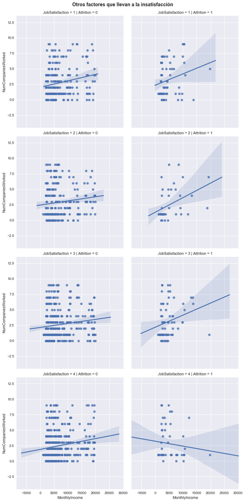

```python
g=sns.FacetGrid(encoded_df,col='Attrition',row='JobSatisfaction',size=5);
g=g.map(sns.regplot,"MonthlyIncome","NumCompaniesWorked");
plt.suptitle("Otros factores que llevan a la insatisfacción",y=1.01,fontsize=14, fontweight='bold');
```

- Se observa que las personas que tienen más experiencia y sus ganancias son mejores, tienden a estar más satisfechos y a quedarse en las compañías.

# 7. Conclusiones factores críticos

A partir del análisis realizado en las secciones anteriores, se concluye que los factores más relevantes para determinar la satisfacción laboral de un empleado son los siguientes:

- Ingreso por hora
- Ingreso por día
- Ingresos mensuales
- Viajes laborales
- Relación vida trabajo
- Años en la compañía
- Años desde la última promoción
- Porcentaje de aumento de salario

## 7.1 Recomendaciones

- Monitorear el nivel de satisfacción de las personas que ganan alrededor de 90/hora
- Verificar el sistema de oportunidades de crecimiento en la empresa, teniendo en cuenta la antiguedad de las personas y el sueldo que estos ganan.
- Tener en cuenta el perfil de las personas que acceden a un cargo que requiere viajar frecuentemente, para evitar problemas con su relación vida-trabajo
- Valorar la experiencia de los trabajadores y tenerla en cuenta para modificar sus sueldos
- Generar capacitaciones para orientar a los empleados en cuanto al balance de su carga laboral y su vida por fuera de la compañía

# 8. DashBoard Monitoreo de indicadores

```python
#!pip install jupyter_dashboards
#!jupyter dashboards quick-setup --sys-prefix
```

## 8.1 Pairplot DashBoard

```python
from ipywidgets import interact

d=['Attrition', 'HourlyRate', 'DailyRate', 'MonthlyIncome','WorkLifeBalance', 'BusinessTravel','JobSatisfaction',
'YearsAtCompany','YearsSinceLastPromotion','PercentSalaryHike','EnvironmentSatisfaction']
@interact(hue=['JobSatisfaction','Attrition'])
def plot(hue):
    _=sns.pairplot(encoded_df[d],hue=hue);
```

## 8.2 Regplot DashBoard

```python
@interact(x=['Attrition', 'HourlyRate', 'DailyRate', 'MonthlyIncome','WorkLifeBalance', 'BusinessTravel','JobSatisfaction',
'YearsAtCompany','YearsSinceLastPromotion','PercentSalaryHike','EnvironmentSatisfaction'],
y=['Attrition', 'HourlyRate', 'DailyRate', 'MonthlyIncome','WorkLifeBalance', 'BusinessTravel','JobSatisfaction','YearsAtCompany',
   'YearsSinceLastPromotion','PercentSalaryHike','EnvironmentSatisfaction'],
          col=['Attrition','JobSatisfaction','EnvironmentSatisfaction'],
         row=['Attrition','JobSatisfaction','EnvironmentSatisfaction'])

def plot(x,y,col,row):
    g=sns.FacetGrid(encoded_df,col=col,row=row,size=5);
    g=g.map(sns.regplot,x,y);
```

## 8.3 Distplot DashBoard - JobSatisfaction

```python
@interact(variable=['Attrition', 'HourlyRate', 'DailyRate', 'MonthlyIncome','WorkLifeBalance', 'BusinessTravel','JobSatisfaction',
'YearsAtCompany','YearsSinceLastPromotion','PercentSalaryHike','EnvironmentSatisfaction'])
def plot(variable):
    sns.distplot(encoded_df[variable][encoded_df['JobSatisfaction']==1],label='Satisfaction=1');
    sns.distplot(encoded_df[variable][encoded_df['JobSatisfaction']==2],label='Satisfaction=2');
    sns.distplot(encoded_df[variable][encoded_df['JobSatisfaction']==3],label='Satisfaction=3');
    sns.distplot(encoded_df[variable][encoded_df['JobSatisfaction']==4],label='Satisfaction=4');
    plt.legend()
```

# 9. Algoritmos de clasificación para predecir la decersión laboral

## 9.1 Preparación del Dataset

```python
from sklearn.preprocessing import MinMaxScaler
from sklearn.preprocessing import StandardScaler

y=encoded_df['Attrition']
xx=encoded_df.drop('Attrition',axis=1)
ScaleFn = MinMaxScaler()
xx = ScaleFn.fit_transform(xx)

# Se aplica un escalamiento a los datos, para tener un mejor desempeño a la hora de aplicar los algoritmo de
# clasificación
```

## 9.2 Aplicación de modelos

```python
from sklearn.cross_validation import train_test_split
from sklearn.metrics import accuracy_score
from sklearn.metrics import classification_report,confusion_matrix
import warnings; warnings.simplefilter('ignore')

# Se divide el dataset con datos de prueba y datos de test

test_size = .30
seedNo = 42

x_train,X_test,y_train,Y_test = train_test_split(xx,y,test_size = test_size, random_state = seedNo)



# Choose algorithm and train
from sklearn.linear_model import LogisticRegression
from sklearn.svm import SVC
from sklearn.tree import DecisionTreeClassifier
from sklearn.ensemble import RandomForestClassifier
from sklearn.neighbors import KNeighborsClassifier
from sklearn.naive_bayes import GaussianNB
from sklearn.neural_network import MLPClassifier
from sklearn.ensemble import AdaBoostClassifier
import xgboost as xgb
from sklearn.ensemble import GradientBoostingClassifier


from sklearn.model_selection import KFold
from sklearn.model_selection import cross_val_score

mymodel = []
mymodel.append(('LogReg', LogisticRegression()))
mymodel.append(('SVM', SVC()))
mymodel.append(('DeciTree', DecisionTreeClassifier()))
mymodel.append(('RandForest', RandomForestClassifier()))
mymodel.append(('KNN', KNeighborsClassifier()))
mymodel.append(('NaiveBayes', GaussianNB()))
mymodel.append(('Neuronal', MLPClassifier()))
mymodel.append(('XGBClassifier', xgb.XGBClassifier()))
mymodel.append(('AdaBoostClassifier', AdaBoostClassifier()))
mymodel.append(('GradientBoostClassifier', GradientBoostingClassifier()))





resultados = {}
cm=[]
for algoname, algorithm in mymodel:


    algorithm.fit(x_train,y_train)
    pred = algorithm.predict(X_test)

    Eval_result=accuracy_score(Y_test, pred)
    resultados[algoname]= Eval_result

    print("Modelo y precisión:", algoname, 100*Eval_result,"%")
    print("")
    print(classification_report(Y_test, pred))
    print("--------------------------------------------------------------")
    cmtemp=confusion_matrix(Y_test, pred)
    cm.append(cmtemp / cmtemp.astype(np.float).sum(axis=1,keepdims=True))
```

```
Modelo y precisión: LogReg 86.84807256235828 %

             precision    recall  f1-score   support

          0       0.89      0.97      0.93       380
          1       0.57      0.21      0.31        61

avg / total       0.84      0.87      0.84       441

--------------------------------------------------------------
Modelo y precisión: SVM 86.16780045351474 %

             precision    recall  f1-score   support

          0       0.86      1.00      0.93       380
          1       0.00      0.00      0.00        61

avg / total       0.74      0.86      0.80       441

--------------------------------------------------------------
Modelo y precisión: DeciTree 78.91156462585033 %

             precision    recall  f1-score   support

          0       0.89      0.86      0.88       380
          1       0.28      0.34      0.31        61

avg / total       0.81      0.79      0.80       441

--------------------------------------------------------------
Modelo y precisión: RandForest 85.4875283446712 %

             precision    recall  f1-score   support

          0       0.87      0.97      0.92       380
          1       0.42      0.13      0.20        61

avg / total       0.81      0.85      0.82       441

--------------------------------------------------------------
```

[output cut: 45 more lines]

```
          1       0.51      0.34      0.41        61

avg / total       0.85      0.86      0.85       441

--------------------------------------------------------------
Modelo y precisión: GradientBoostClassifier 87.98185941043084 %

             precision    recall  f1-score   support

          0       0.90      0.97      0.93       380
          1       0.64      0.30      0.40        61

avg / total       0.86      0.88      0.86       441

--------------------------------------------------------------
```

## 9.3 Visualización de resultados

```python
resultadosncv = pd.DataFrame.from_dict(resultados,orient='index')
resultadosncv.columns=["Accuracy"]
resultadosncv = resultadosncv.sort_values(by=["Accuracy"],ascending=False)

resultadosncv
```

|  | Accuracy |
| --- | --- |
| GradientBoostClassifier | 0.879819 |
| Neuronal | 0.877551 |
| XGBClassifier | 0.877551 |
| LogReg | 0.868481 |
| KNN | 0.863946 |
| AdaBoostClassifier | 0.863946 |
| SVM | 0.861678 |
| RandForest | 0.854875 |
| DeciTree | 0.789116 |
| NaiveBayes | 0.764172 |

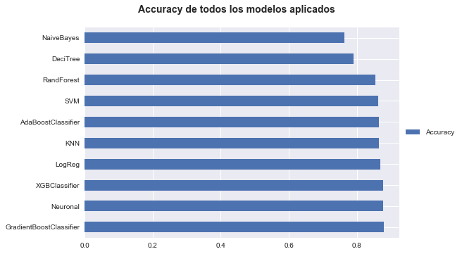

```python
resultadosncv[["Accuracy"]].plot.barh();
plt.legend(loc='center left', bbox_to_anchor=(1.0, 0.5));
plt.suptitle("Accuracy de todos los modelos aplicados",y=0.96,fontsize=14, fontweight='bold');
```

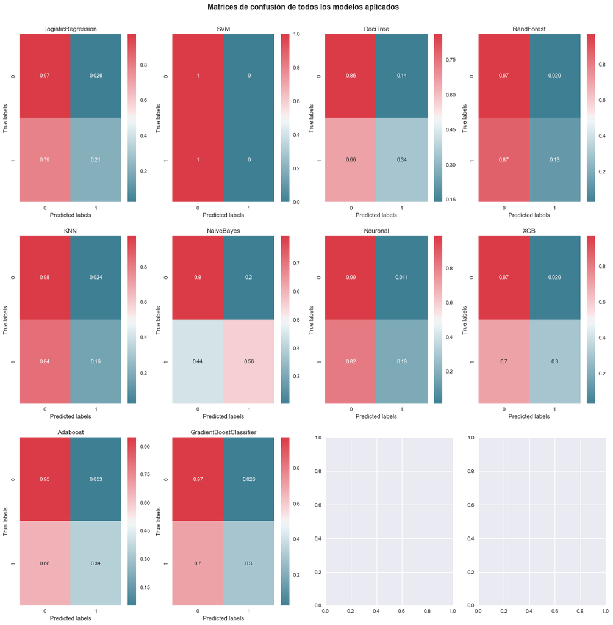

```python
labels=['0','1']
cmap=sns.diverging_palette(220,10,as_cmap=True)
fig, axes=plt.subplots(nrows=3, ncols=4, figsize=(20,20));
All_model_name=['LogisticRegression','SVM','DeciTree','RandForest','KNN','NaiveBayes','Neuronal','XGB','Adaboost',
                'GradientBoostClassifier']

plt.suptitle("Matrices de confusión de todos los modelos aplicados",y=0.92,fontsize=14, fontweight='bold');
contador=0;
for x in range(3):
    for y in range(4):
        try:
            sns.heatmap(cm[contador], annot=True, ax=axes[x,y], cmap=cmap); #annot=True to annotate cells
            # labels, title and ticks
            axes[x,y].set_xlabel('Predicted labels');axes[x,y].set_ylabel('True labels');
            axes[x,y].set_title(All_model_name[contador]);
            axes[x,y].xaxis.set_ticklabels(labels); axes[x,y].yaxis.set_ticklabels(labels);
            contador+=1
            if contador==10: break
        except: break
```

- Al analizar los resultados con la matriz de confusión, se concluye que para la clase 0 (no abandono) la tasa de acierto es muy alta con la maoría de los resultados, sin embargo para la clase 1 (abandono) los resultados sonmuy pobres. Esta situación se puede explicar debido a que los datos de entrada se encuentran evidentemente desbalanceados en la medida en que tienen pocos registros que correspondan a personas que abandonaron la compañía.
- De acuerdo con los resultados de la matriz de confusión, los algoritmos con mejor desempeño son:

  ```
   - Adaboost
   - XGB
   - NaiveBayes
   - Gradient Boost Classifier
  ```

## 9.4 Cross-Validation

```python
import warnings; warnings.simplefilter('ignore')
seedNo = 42

y=encoded_df['Attrition']
xx=encoded_df.drop('Attrition',axis=1)
ScaleFn = MinMaxScaler()
xx = ScaleFn.fit_transform(xx)

# Choose algorithm and train
from sklearn.linear_model import LogisticRegression
from sklearn.svm import SVC
from sklearn.tree import DecisionTreeClassifier
from sklearn.ensemble import RandomForestClassifier
from sklearn.neighbors import KNeighborsClassifier
from sklearn.naive_bayes import GaussianNB
from sklearn.neural_network import MLPClassifier
from sklearn.ensemble import AdaBoostClassifier
import xgboost as xgb
from sklearn.ensemble import GradientBoostingClassifier


from sklearn.model_selection import KFold
from sklearn.model_selection import cross_val_score

mymodel = []
mymodel.append(('LogReg', LogisticRegression()))
mymodel.append(('SVM', SVC()))
mymodel.append(('DeciTree', DecisionTreeClassifier()))
mymodel.append(('RandForest', RandomForestClassifier()))
mymodel.append(('KNN', KNeighborsClassifier()))
mymodel.append(('NaiveBayes', GaussianNB()))
mymodel.append(('Neuronal', MLPClassifier()))
mymodel.append(('XGBClassifier', xgb.XGBClassifier()))
mymodel.append(('AdaBoostClassifier', AdaBoostClassifier()))
mymodel.append(('GradientBoostClassifier', GradientBoostingClassifier()))



resultados={}

for algoname, algorithm in mymodel:
    kfoldFn = KFold(n_splits = 10, random_state = seedNo)
    Eval_result = cross_val_score(algorithm, xx, y, cv = kfoldFn, scoring = 'accuracy')
    resultados[algoname]=Eval_result.mean()

    print("Modelo y precisión:", algoname, 100*Eval_result.mean(),"%")
```

```
Modelo y precisión: LogReg 86.53061224489797 %
Modelo y precisión: SVM 83.87755102040815 %
Modelo y precisión: DeciTree 77.61904761904762 %
Modelo y precisión: RandForest 85.37414965986393 %
Modelo y precisión: KNN 83.9455782312925 %
Modelo y precisión: NaiveBayes 78.16326530612245 %
Modelo y precisión: Neuronal 86.59863945578232 %
Modelo y precisión: XGBClassifier 86.5986394557823 %
Modelo y precisión: AdaBoostClassifier 87.95918367346938 %
Modelo y precisión: GradientBoostClassifier 86.5986394557823 %
```

## 9.5 Visualización de resultados

```python
resultadoscv = pd.DataFrame.from_dict(resultados,orient='index')
resultadoscv.columns=["Accuracy-cv"]
resultadoscv = resultadoscv.sort_values(by=["Accuracy-cv"],ascending=False)

resultadoscv
```

|  | Accuracy-cv |
| --- | --- |
| AdaBoostClassifier | 0.879592 |
| Neuronal | 0.865986 |
| XGBClassifier | 0.865986 |
| GradientBoostClassifier | 0.865986 |
| LogReg | 0.865306 |
| RandForest | 0.853741 |
| KNN | 0.839456 |
| SVM | 0.838776 |
| NaiveBayes | 0.781633 |
| DeciTree | 0.776190 |

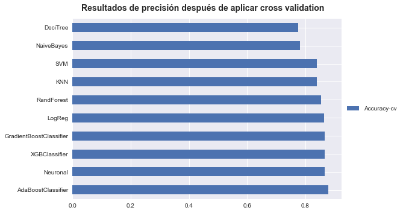

```python
resultadoscv[["Accuracy-cv"]].plot.barh();
plt.legend(loc='center left', bbox_to_anchor=(1.0, 0.5));
plt.suptitle("Resultados de precisión después de aplicar cross validation",y=0.94,fontsize=14, fontweight='bold');
```

## 9.6 Comparación de resultados

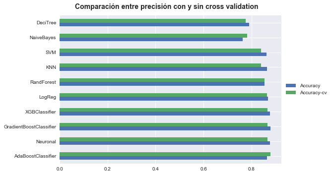

```python
## comparación

resultadosncv=resultadosncv.join(resultadoscv)
resultadosncv = resultadosncv.sort_values(by=["Accuracy-cv"],ascending=False)

resultadosncv[["Accuracy", "Accuracy-cv"]].plot.barh()
plt.legend(loc='center left', bbox_to_anchor=(1.0, 0.5))
plt.suptitle("Comparación entre precisión con y sin cross validation",y=0.94,fontsize=14, fontweight='bold');
```

#### Al realizar el proceso de Cross Validation, el clasificador que obtiene un mejor resultado de precisión es el Adaboost

```python
resultadosncv
```

|  | Accuracy | Accuracy-cv |
| --- | --- | --- |
| AdaBoostClassifier | 0.863946 | 0.879592 |
| Neuronal | 0.877551 | 0.865986 |
| GradientBoostClassifier | 0.879819 | 0.865986 |
| XGBClassifier | 0.877551 | 0.865986 |
| LogReg | 0.868481 | 0.865306 |
| RandForest | 0.854875 | 0.853741 |
| KNN | 0.863946 | 0.839456 |
| SVM | 0.861678 | 0.838776 |
| NaiveBayes | 0.764172 | 0.781633 |
| DeciTree | 0.789116 | 0.776190 |

## 9.7 Hyperparameter Tunnig

- Se realiza la optimización de hiperparametros con uno de los modelos que obtuvo mejor desempeño, para intentar mejorar los resultados.

```python
import warnings; warnings.simplefilter('ignore')
from sklearn.model_selection import GridSearchCV

# A parameter grid for XGBoost

params = {
        'min_child_weight': [1, 5, 10],
        'gamma': [0.5, 1, 1.5, 2, 5],
        'subsample': [0.6, 0.8, 1.0],
        'colsample_bytree': [0.6, 0.8, 1.0],
        'max_depth': [3, 4, 5]
        }

gridxg = GridSearchCV(xgb.XGBClassifier(), params, cv=5, verbose=0)
gridxg.fit(xx, y)
print(gridxg.best_estimator_)
print(' ')
print(gridxg.best_score_)
```

```
XGBClassifier(base_score=0.5, booster='gbtree', colsample_bylevel=1,
       colsample_bytree=1.0, gamma=2, learning_rate=0.1, max_delta_step=0,
       max_depth=3, min_child_weight=10, missing=None, n_estimators=100,
       n_jobs=1, nthread=None, objective='binary:logistic', random_state=0,
       reg_alpha=0, reg_lambda=1, scale_pos_weight=1, seed=None,
       silent=True, subsample=0.6)

0.8816326530612245
```

#### Luego del proceso de optmización,se obtuvieron los mejores parámetros para el modelo y el score asociado a dicho modelo.